# Part II - Insight into the performance of borrowers and how it can supprt the decision making process of the company for maximal profit and minimal loss

## by Olalekan Akinpelu

## Investigation Overview

The goal of our presentation is to provide quality insight that can help the company make better decisions, which can then help maximise profit and minimise loss. We will be doing this by presenting to you the performance of borrowers with respect to the status of their dept and the returns from it.

## Dataset Overview

The dataset we analysed is a Loan Data from Prosper. It contains 113,937 loans with 81 variables on each loan, including loan amount, borrower rate (or interest rate), current loan status, borrower income, and many others.

## (Visualization 1)

From our early analysis, we realise that there is no form of relationship between Estimated Returns and Actual Returns. Which means that what the company do estimate to be the return they will get doesn't align with the actual return.

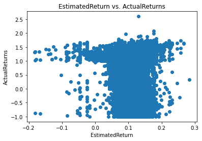

## (Visualization 2)

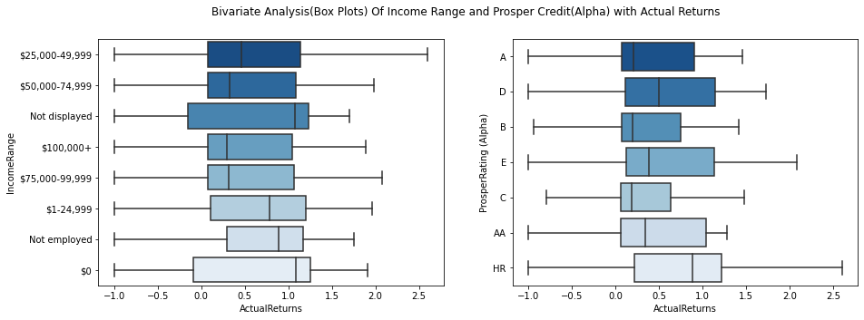

## (Visualization 3)

According to logical deduction, we can say that High Prosper credit ratings are not only allocated to those with High income range, Meaning income ranges are not only what are used for the determination of ratings. This further buttress our point that the company shouldn't associate high income range with actual return.

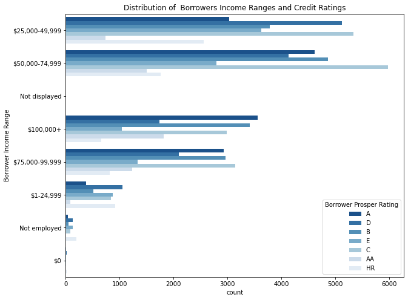

## Conclusion

Our analysis is a testimony to the fact that data analysis (collection and analysis of data) is key to making good business or organisational decisions, and this company must priortise it. Relying on intuition alone is not wise as proven by our report. Our mere intuition may make us believe that in a situation where some of the borrowers pay on time or high return was derived from them, people with high income will always perform better while people with low income will not. It is not always correct to think this way.